# Análisis de Enlaces Web

# Sección 4 - limma.php

## limma Results

In this section the differential expression results generated by the limma method are shown.(1)

The following text files (can be opened in Excel) they contains the result of differential expression analysis for all genes with significant counts. The meaning of each column is described below. :

id : The first column is the id(gene, transcript, etc.), log2FoldChange : The log fold-change between conditions being tested AveExpr: Average log2 expression t: the t-statistic used to assess differential expression P.Value: The p-value for differential expression; this value is not adjusted for multiple testing adj.P.Val :The p-value adjusted for multiple testing B: The B-statistic is the log-odds that the gene is differentially expressed The last columns correspond to: raw counts: Raw counts for all sample normalized counts: Normalized counts for all samples Regulation : gene regulation, indicating how and in which condition the genes was expressed

- `pEhExvsU2AF84_pval.txt`
- `pEhExvsEhMyb10.txt`
- `pEhExvsUmasM.txt`
- `pEhExvsCDC5.txt`
- `pEhExvsEhMyb10_Abundances.txt`
- `pEhExvsU2AF84_TOP.txt`
- `pEhExvsUmasM_logFC.txt`
- `pEhExvsCmasM.txt`
- `pEhExvsCmasM_Abundances.txt`
- `pEhExvsUmasM_TOP.txt`
- `pEhExvsUmasM_pval.txt`
- `pEhExvsU2AF84_Abundances.txt`
- `pEhExvsU2AF84_logFC.txt`
- `pEhExvsCDC5_logFC.txt`
- `pEhExvsCmasM_logFC.txt`
- `pEhExvsCDC5_Abundances.txt`
- `pEhExvsUmasM_Abundances.txt`
- `pEhExvsEhMyb10_TOP.txt`
- `pEhExvsCDC5_pval.txt`
- `pEhExvsEhMyb10_pval.txt`
- `pEhExvsCmasM_TOP.txt`
- `pEhExvsEhMyb10_logFC.txt`
- `pEhExvsCDC5_TOP.txt`
- `pEhExvsCmasM_pval.txt`
- `pEhExvsU2AF84.txt`

- `pEhExvsU2AF84_TOP.txt`
- `pEhExvsUmasM_TOP.txt`
- `pEhExvsEhMyb10_TOP.txt`
- `pEhExvsCmasM_TOP.txt`
- `pEhExvsCDC5_TOP.txt`

## Graph PlotPCA

**Click to enlarge the image**

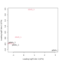

[figure not shown]

[figure not shown]

[figure not shown]

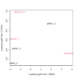

[figure not shown]

[figure not shown]

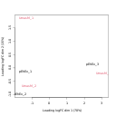

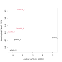

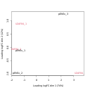

# Sección 5 - NOISeq.php

## NOISeq Results

In this section the differential expression results generated by the NOISeq method are shown. (1)

The following text files (can be opened in Excel) they contains the result of differential expression analysis for all genes with significant counts. The meaning of each column is described below. :

1. id : The first column is the id(gene, transcript, etc.)
2. Cond1_mean: The second column is the mean of the biological replicates of first condition
3. Cond2_mean: the thirds column is the mean of the biological replicates of secondth condition
4. theta: the fourth column is a Differential expression statistics
5. Prop: the fifth column show Probability of differential expression
6. log2FoldChange : The log fold-change between conditions being tested The last columns correspond to:
7. raw counts: Raw counts for all sample
8. normalized counts: Normalized counts for all samples
9. DE: gene regulation, indicating how and in which condition the genes was expressed
- `pEhExvsU2AF84_pval.txt`
- `pEhExvsEhMyb10.txt`
- `pEhExvsUmasM.txt`
- `pEhExvsCDC5.txt`
- `pEhExvsEhMyb10_Abundances.txt`
- `pEhExvsU2AF84_TOP.txt`
- `pEhExvsUmasM_logFC.txt`
- `pEhExvsCmasM.txt`
- `pEhExvsCmasM_Abundances.txt`
- `pEhExvsUmasM_TOP.txt`
- `pEhExvsUmasM_pval.txt`
- `pEhExvsU2AF84_Abundances.txt`
- `pEhExvsU2AF84_logFC.txt`
- `pEhExvsCDC5_logFC.txt`
- `pEhExvsCmasM_logFC.txt`
- `pEhExvsCDC5_Abundances.txt`
- `pEhExvsUmasM_Abundances.txt`
- `pEhExvsEhMyb10_TOP.txt`
- `pEhExvsCDC5_pval.txt`
- `pEhExvsEhMyb10_pval.txt`
- `pEhExvsCmasM_TOP.txt`
- `pEhExvsEhMyb10_logFC.txt`
- `pEhExvsCDC5_TOP.txt`
- `pEhExvsCmasM_pval.txt`
- `pEhExvsU2AF84.txt`

## Subgrupos

The following files with TOP.txt ending, it are subgroup of previos files, and it containing DE results only of the differentially expressed genes (considering the established cutoff parameters).

- `pEhExvsU2AF84_TOP.txt`
- `pEhExvsUmasM_TOP.txt`
- `pEhExvsEhMyb10_TOP.txt`
- `pEhExvsCmasM_TOP.txt`
- `pEhExvsCDC5_TOP.txt`

## Differential expressed

The following files have genes that it was reported as differential expressed for more than one method,(NOISeq + others)

- `pEhExvsCDC5_Intersect.txt`
- `pEhExvsEhMyb10_Intersect.txt`
- `pEhExvsCmasM_Intersect.txt`

# Sección 6 - VennDiagram.php

## Results Integration

Once the results of the differential expression analyses has been obtained (by the different selected methods), these results are compared, by mean of Venn, bar and correlograms plots, in order to see how the different methods agree on the final list of differential expressed genes

In the process of integration of results, different files are obtained. These files contain information related to the differentially expressed genes found at the intersection of all methods. The description of the files is as follows:

Files with _table.txt ending: File of binary values, which indicate for each gene, the methods that report it as differentially expressed. In the last column of the file, a description of the gene regulation can be found, where is indicated how and in which condition the genes was expressed.

Files with _IntersectSummary.txt ending: Contains the summary of the number of DE genes in all possible logical relationships between the different methods

Files with _Intesrsect_TOP_IDs.txt ending: Table that contains the ID of those genes that are at the intersection of the DE genes obtained by all the different selected methods.

Files with _logFCTable.txt ending: Table containing the logFC values of the DE genes reported for all methods

Files with _AbundanceTable.txt ending: Table containing the raw and normalized counts of all samples of the DE genes reported for all methods

Files with _PvalTable.txt ending: Table containing the padjust/FDR values of the DE genes reported for all methods

- `pEhExvsEhMyb10_matrixWeight.txt`
- `pEhExvsEhMyb10_Union_TOP_IDs.txt`
- `pEhExvsCDC5_IntersectSummary.txt`
- `pEhExvsEhMyb10_AbundanceTable.txt`
- `pEhExvsCmasM_AbundanceTable.txt`
- `pEhExvsCmasM_table.txt`
- `pEhExvsCDC5_Intesrsect_TOP_IDs.txt`
- `pEhExvsEhMyb10_PvalTable.txt`
- `pEhExvsCDC5_Union_TOP_IDs.txt`
- `pEhExvsEhMyb10_table.txt`
- `pEhExvsCDC5_logFCTable.txt`
- `pEhExvsEhMyb10_logFCTable.txt`
- `pEhExvsCmasM_Intesrsect_TOP_IDs.txt`
- `pEhExvsEhMyb10_IntersectSummary.txt`
- `pEhExvsCmasM_logFCTable.txt`
- `pEhExvsCmasM_matrixWeight.txt`
- `pEhExvsCmasM_IntersectSummary.txt`
- `pEhExvsCDC5_table.txt`
- `pEhExvsCDC5_AbundanceTable.txt`
- `pEhExvsCmasM_Union_TOP_IDs.txt`
- `pEhExvsCDC5_PvalTable.txt`
- `pEhExvsEhMyb10_Intesrsect_TOP_IDs.txt`
- `pEhExvsCDC5_matrixWeight.txt`
- `pEhExvsCmasM_PvalTable.txt`

The Venn diagram shows the intersection of the differentially expressed genes reported by each of the selected methods. Further analysis could be considered only in the list of genes that were identified as differentials expressed by more than one method. (In the center of the graph)

## Diagramas de Venn

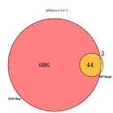

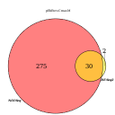

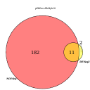

## Graficos

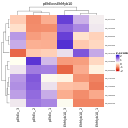

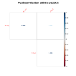

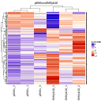

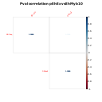

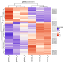

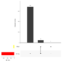

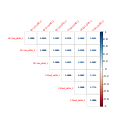

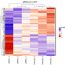

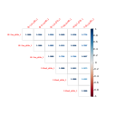

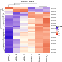

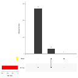

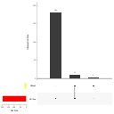

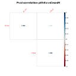

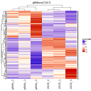

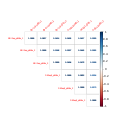